# Patient Linkage and Retention

## Context

- The Patient Linkage and Retention (PLR) is a Community health tracking system
- The system allows the tracking of Patient for different reason
  - Lost to Follow Up
  - Missed Appointment
  - Community Drug Distribution
  - Geo-location
  - PreART patients Not on ART
  - HIV+ patients Not Enrolled
- Patient are contacted or tracked (follow up Type) by **Phone Call** or **Home visit**

## Data Analysis

- We have extracted all patient tracking records from the database.
- We have uploaed data from **2015-03-18** to **2017-08-03**
- During that period we have done **114556** tracking for **53085** unique patient for all reasons.
- Those activities has been performed over the time in **73** facilities from 6 partners
  - UGP MSPP
  - GHESKIO
  - CMMB
  - PHI
  - CDS
  - FOSREF

## Tracking by Reason

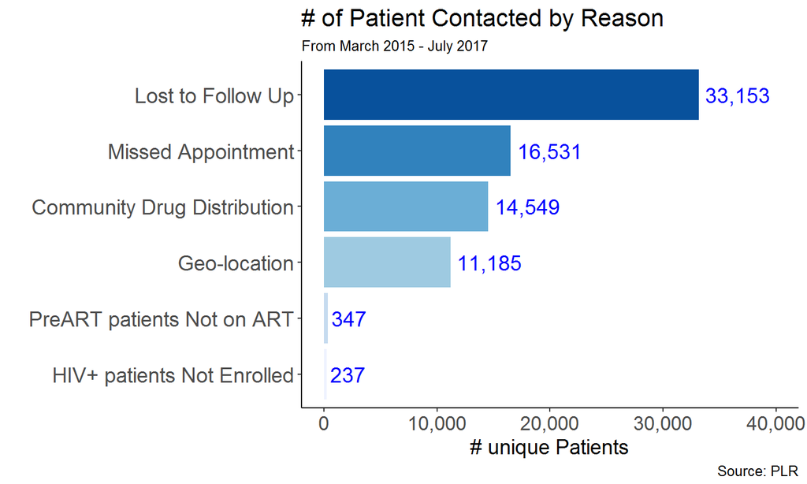

## Tracking by FollowUp type

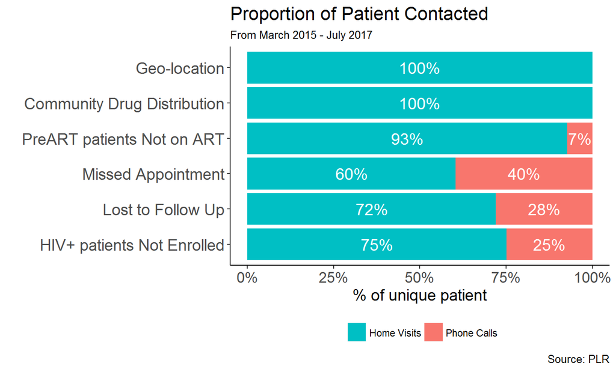

## Overall Tracking Trend

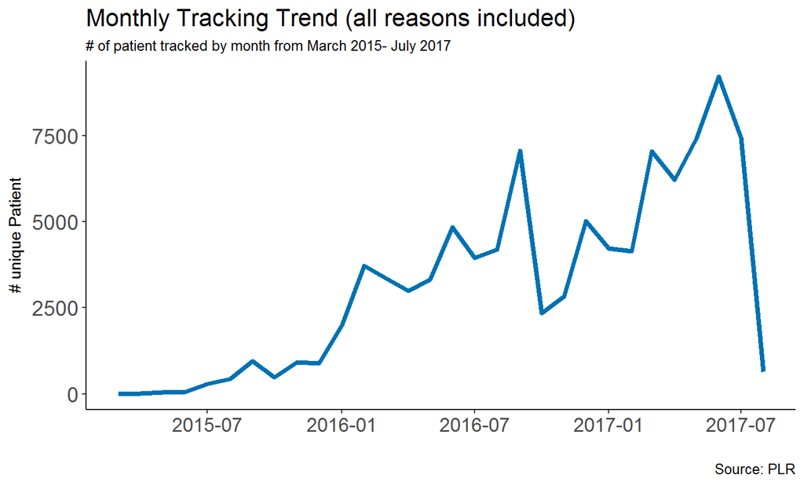

## Trend by Reason

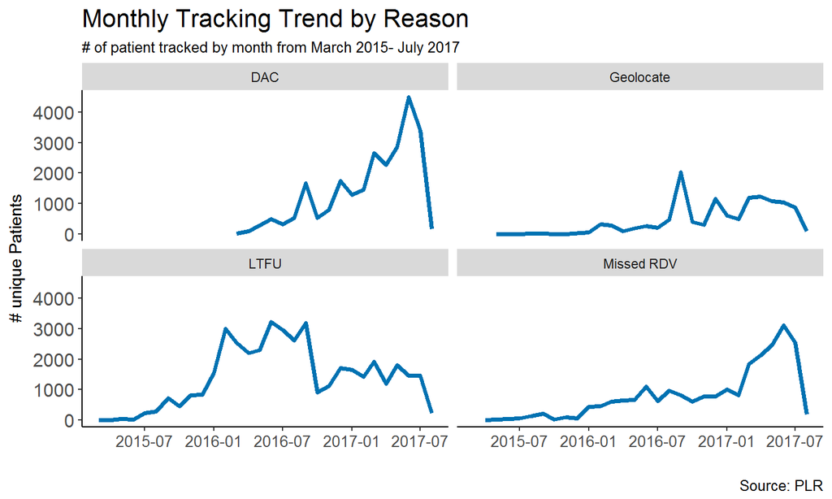

## Other way to look at it

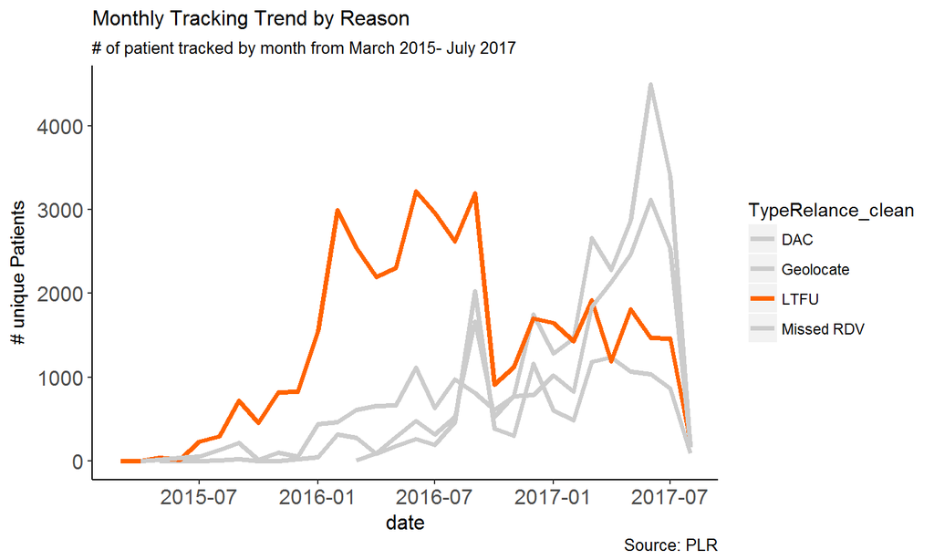

## Lost to Follow-Up (LTFU)

## LTFU

- This section show key results for LTFU tracking activities
- From **2015-03-18** to **2017-08-03** we have conducted **46606** tracking activities and tracked **33153** LTFU unique patients
- For LTFU patients contacted PLR registers different outcomes
  - Patient is Dead
  - Patient refuse to come back
  - Patient continue treatement in another facility
  - Patient came back to the clinic
  - Patient is not found (no outcome found)

## Tracking LTFU by Sexe

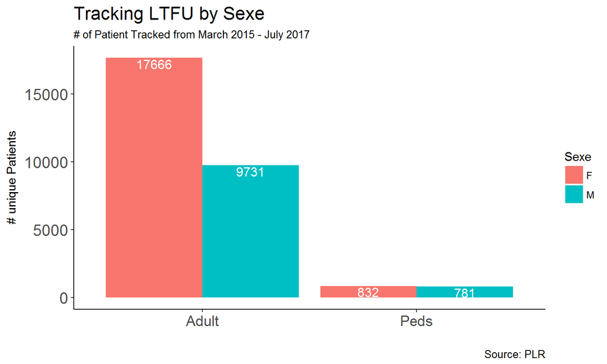

## Tracking LTFU by FollowUp Type

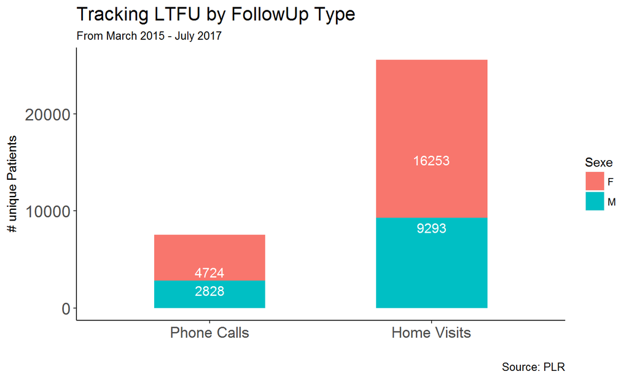

## LTFU Tracking Trend by Follow Up Type

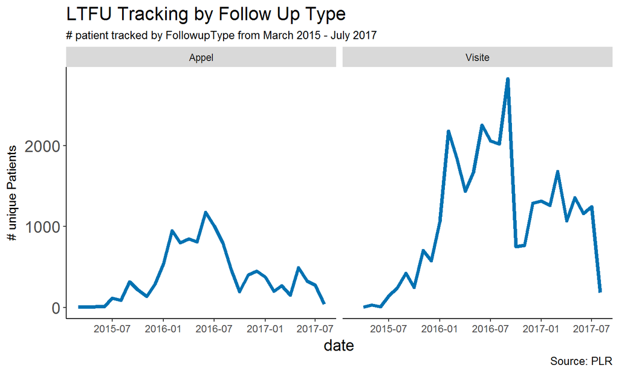

## LTFU Monthly Tracking by Sexe

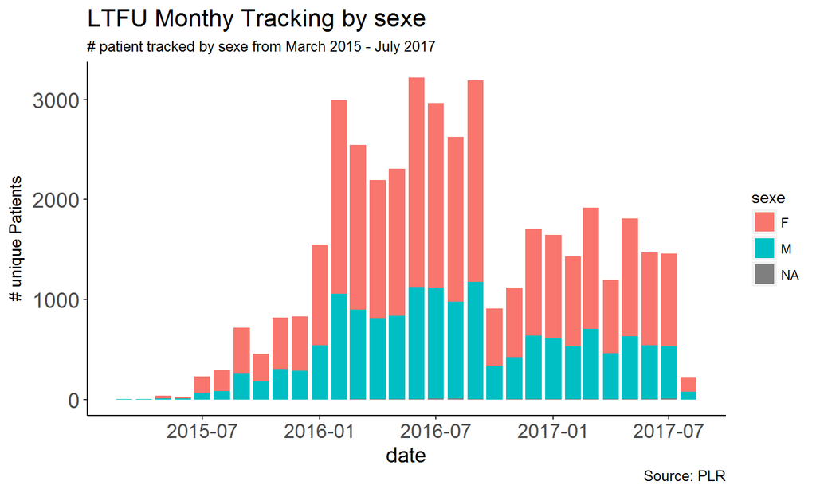

## Cumulative trend

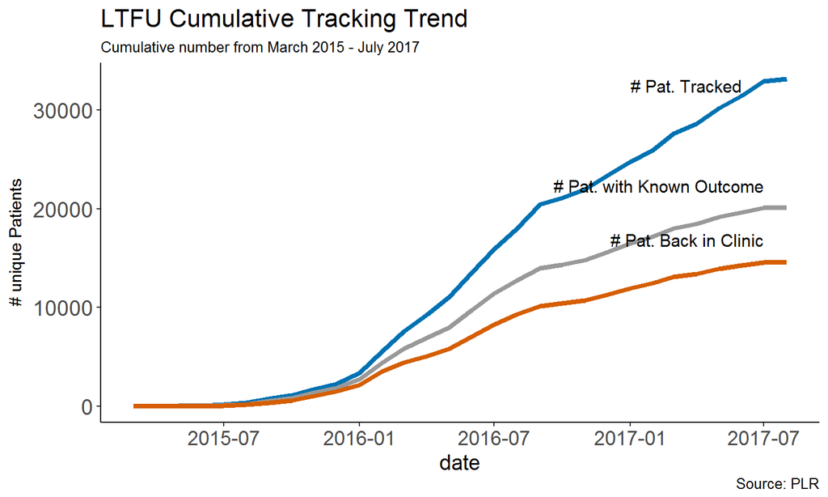

## LTFU Tracking Results

- As in PLR dashboard we have looked at LTFU Tracking Performance
- **Tracking Performance** = *# Pat. Returned to clinic*/ *# Patient contacted*
- We have introduced the known outcomes variable
- Number of Pat. with KnownOutcomes includes :
  - Patient is Dead
  - Patient is Transfered
  - Patient refuse treatment
  - Patient came back to clinic

## LTFU Tracking Performance Trend

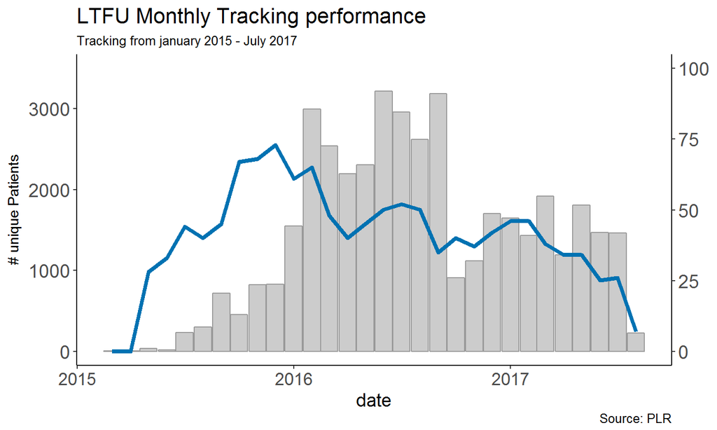

## LTFU Tracking Performance by Partner

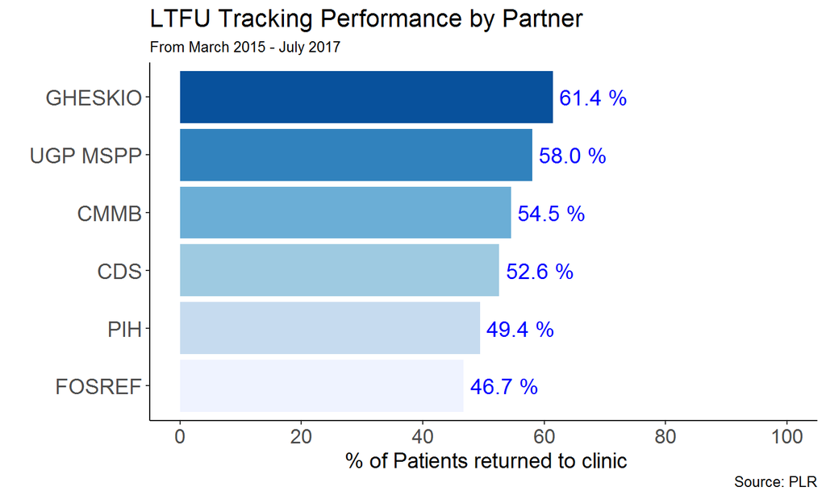

## LTFU Tracking Performance by Partner

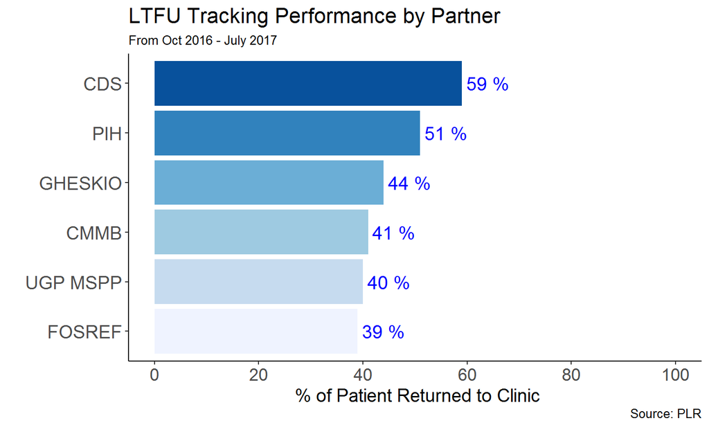

## LTFU Tracking Perfomance Cascade

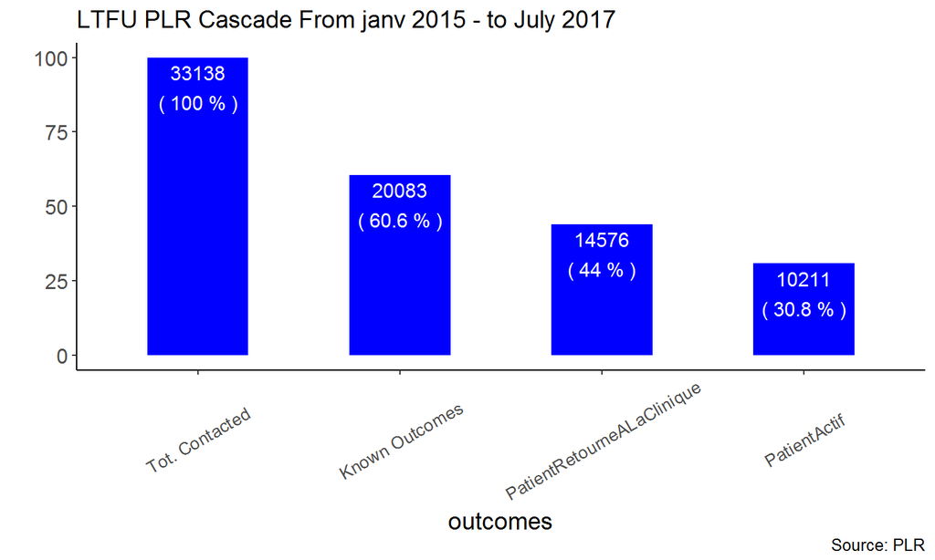

## LTFU Flowchart of outcomes

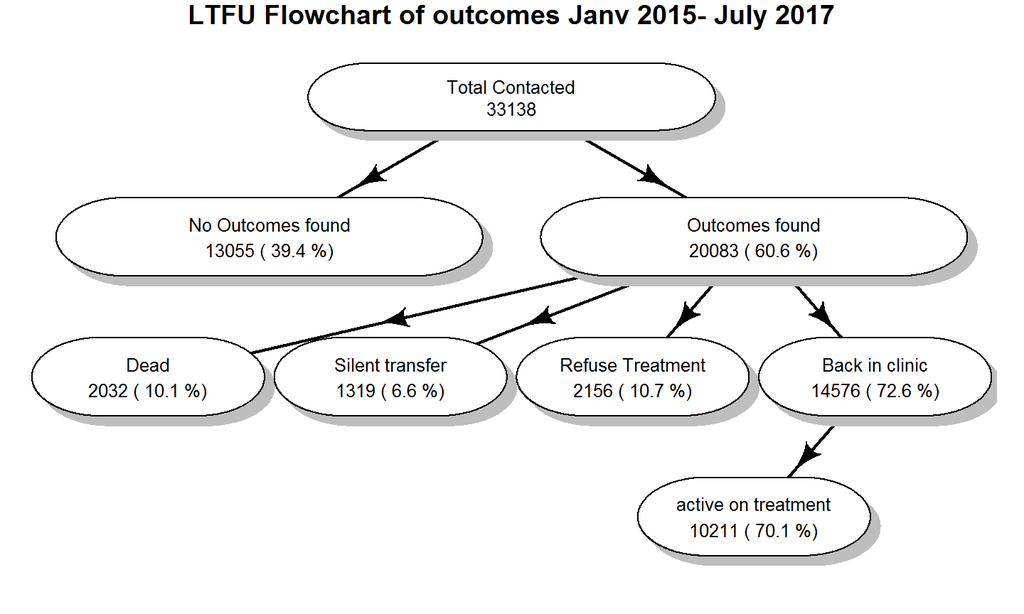

## LTFU Partner Outcome Cascade

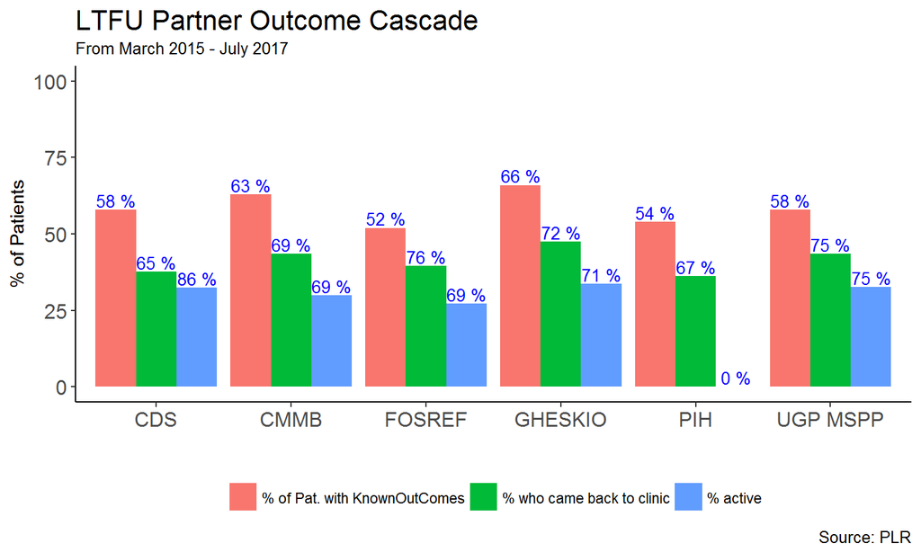

## LTFU Partner Outcome Cascade

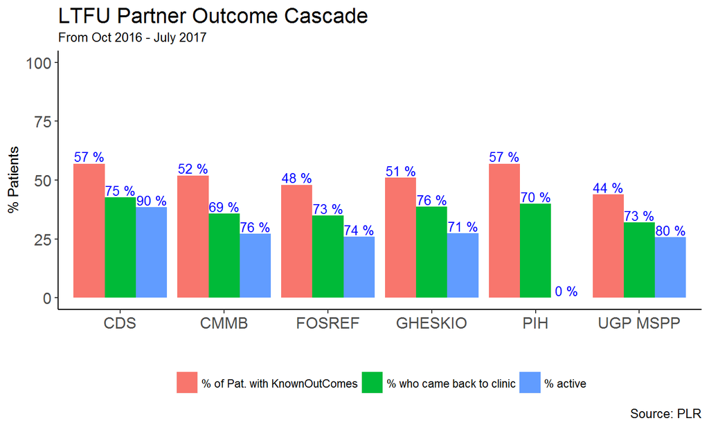

## Overall Findings

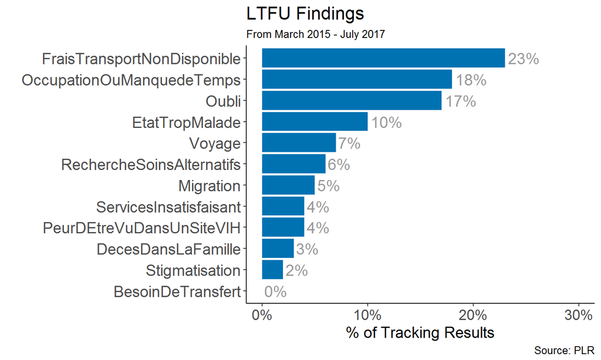

## Overall Findings by Sexe (Male)

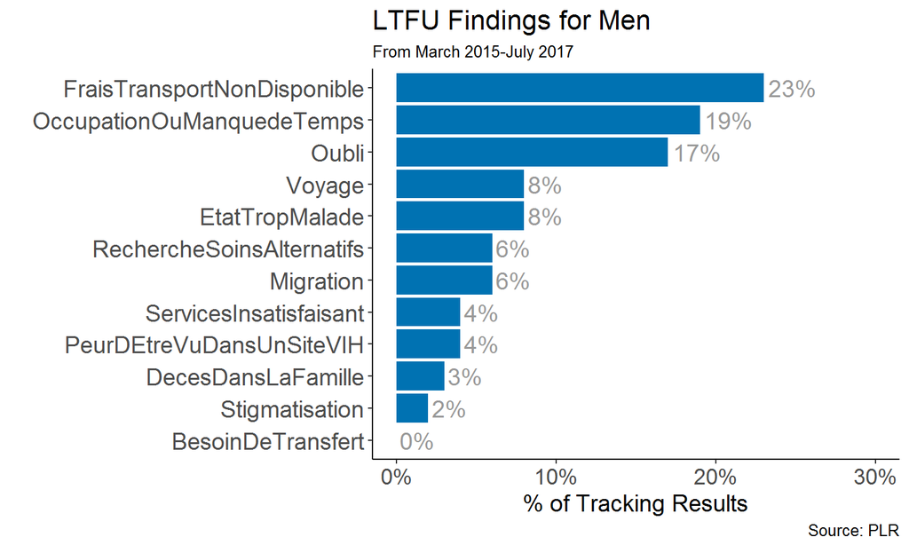

## Overall Findings by Sexe (Female)

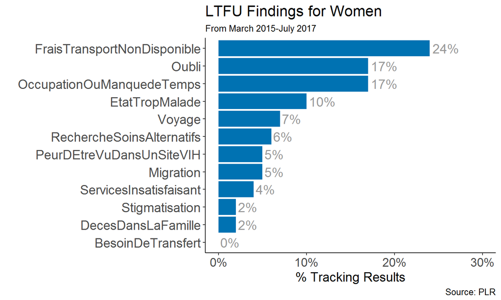

## Conclusion

- Our overall tracking activities has increased the past 3 years
- However there is a competion between the different activities
- LTFU activities has decreased in FY17 but we have an increase of activities in Community Drug Distribution.
- The LTFU tracking performance has decreased in FY17.
- For FY17 all partners are below **60%** tracking performance
- For the past 3 year **44%** of the Patient Contacted Came back to the clinic.
- We dont know the outcomes for **40%** of our LTFU and **10%** of those found refuse to came back.

## Next Steps

- For now we have only looked at basic resutls for LTFU
- We need to go deeper in LTFU analysis and cascade.
- Improve and better define key performance indicator for PLR
- We need to analyze data for other activities
  - Missed Appointment
  - Community Drug Distribution
  - Geo-Location
- Intregrate findings with EMR data
- Create static and interactive maps
- Find a better way to show the impact of LTFU tracking on TX_CURR